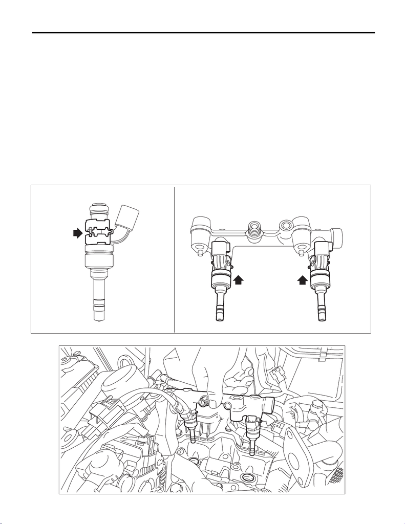

FU(w/o STI)-71

Fuel Pressure Sensor

FUEL INJECTION (FUEL SYSTEMS)

8. Fuel Pressure Sensor

A: REMOVAL

CAUTION:

• Be careful not to spill fuel.

• Catch the fuel from the pipes using a container or cloth.

1) Disconnect the ground terminal from battery sensor. <Ref. to NT-5, BATTERY, NOTE, Note.>

2) Remove the intake manifold. <Ref. to FU(w/o STI)-18, REMOVAL, Intake Manifold.>

3) Remove the fuel injector RH. <Ref. to FU(w/o STI)-51, FUEL INJECTOR RH, REMOVAL, Fuel Injector.>

B: INSTALLATION

1) Replace injector seal, retainer, and O-ring with a new part. <Ref. to FU(w/o STI)-64, REPLACEMENT,

Fuel Injector.>

2) Set the holder to the fuel injector, and install it to the fuel injector pipe RH.

CAUTION:

• Always use a new holder.

• Always use a new fuel injector pipe RH.

3) Install the fuel injector pipe RH and fuel injector as a single unit to the cylinder head.

FU-07520

FU-07852

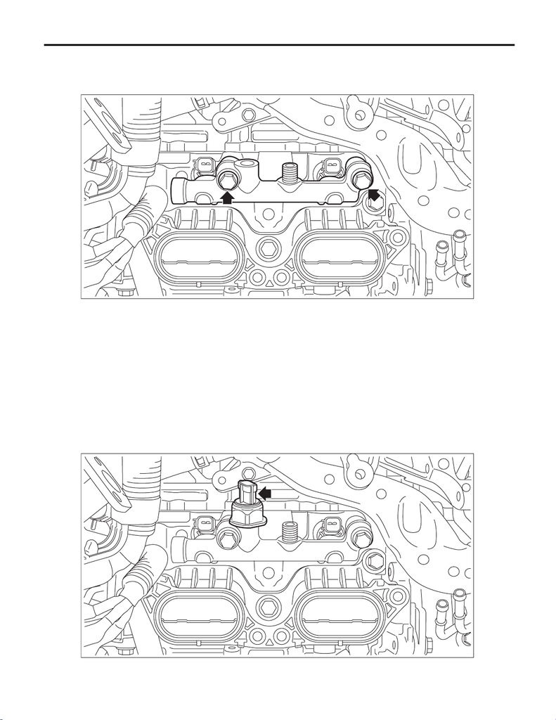

FU(w/o STI)-72

Fuel Pressure Sensor

FUEL INJECTION (FUEL SYSTEMS)

4) Tighten the fuel injector pipe RH.

Tightening torque:

19 N·m (1.9 kgf-m, 14.0 ft-lb)

5) Temporarily tighten the fuel pressure sensor to the fuel injector pipe RH until it cannot be turned by hand.

CAUTION:

Always use a new fuel pressure sensor.

6) Tighten the fuel pressure sensor.

CAUTION:

• Be careful not to spill oil on the screw sections of the fuel pressure sensor and the fuel injector

pipe RH.

• Be careful not to let foreign matter enter into the fuel pressure sensor during installation.

• Do not recheck the tightening torque after tightening the fuel pressure sensor with specified

torque.

Tightening torque:

46 N·m (4.7 kgf-m, 33.9 ft-lb)

FU-07418

FU-07419

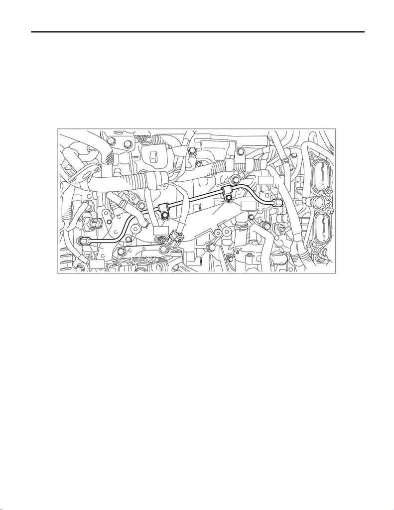

FU(w/o STI)-73

Fuel Pressure Sensor

FUEL INJECTION (FUEL SYSTEMS)

7) Install the high-pressure fuel delivery pipe assembly.

CAUTION:

Always use a new high-pressure fuel delivery pipe assembly.

(1) Temporarily tighten the flare nut (A) to the fuel injector pipe by hand until it is seated, and secure the

high-pressure fuel delivery pipe assembly to the water pipe assembly using bolts (B).

Tightening torque:

T1: 6.4 N·m (0.7 kgf-m, 4.7 ft-lb)

(2) Tighten the flare nuts (A).

Tightening torque:

T2: 25 N·m (2.5 kgf-m, 18.4 ft-lb)

8) Install the fuel pipe insulator No. 3. <Ref. to FU(w/o STI)-50, FUEL PIPE INSULATOR NO. 3, INSTALLA-

TION, Fuel Insulator.>

9) Install the fuel pipe insulator No. 2. <Ref. to FU(w/o STI)-50, FUEL PIPE INSULATOR NO. 2, INSTALLA-

TION, Fuel Insulator.>

10) Install the fuel pipe insulator No. 1. <Ref. to FU(w/o STI)-49, FUEL PIPE INSULATOR NO. 1, INSTAL-

LATION, Fuel Insulator.>

11) Install the intake manifold. <Ref. to FU(w/o STI)-29, INSTALLATION, Intake Manifold.>

12) Connect the ground terminal to battery sensor. <Ref. to NT-5, BATTERY, NOTE, Note.>

C: INSPECTION

Check that the fuel pressure sensor has no deformation, cracks or other damages.

(B)

(A)

(A)

(B)

FU-08468

T2

T1

T1

T2